# Lecture 5 Causal Diagrams

Nick Huntington-Klein

2021-02-24

## Recap

- Last time we talked about identification
- There’s a theoretical concept we’re trying to get at, and we want to pick out *just the variation* that represents that effect
- We also talked about *how* we can identify causality in data
- Part of that will necessarily require us to have a model

## Models

- We *have to have a model* to get at causality
- A model is our way of *understanding the world*. It’s our idea of what we think the data-generating process is
- Models can be informal or formal - “The sun rises every day because the earth spins” vs. super-complex astronomical models of the galaxy with thousands of equations
- All models are wrong. Even quantum mechanics. But as long as models are right enough to be useful, we’re good to go!

## Models

- Once we *do* have a model, though, that model will tell us *exactly* how we can find a causal effect
- (if it’s possible; sometimes the model says that to identify we must do something impossible)
- Just like Arteaga did, if we know a source of identified variation in how `X` was assigned, and using that information we were able to get a good estimate of the true treatment

## Example

- Let’s work through a basic example where we know the data generating process

```r
# Is your company in tech? Let's say 30% of firms are
df <- tibble(tech = sample(c(0,1),500,replace=T,prob=c(.7,.3))) %>%
  #Tech firms on average spend $3mil more defending IP lawsuits
  mutate(IP.spend = 3*tech+runif(500,min=0,max=4)) %>%
  #Tech firms also have higher profits. But IP lawsuits lower profits
  mutate(log.profit = 2*tech - .3*IP.spend + rnorm(500,mean=2))
# Now let's check for how profit and IP.spend are correlated!
cor(df$log.profit,df$IP.spend)
```

```
## [1] 0.1820006
```

- Uh-oh! Truth is negative relationship, but data says positive!!

## Example

- Now we can ask: *what do we know* about this situation?
- How do we suspect the data was generated? (ignoring for a moment that we know already)
  - We know that being a tech company leads you to have to spend more money on IP lawsuits
  - We know that being a tech company leads you to have higher profits
  - We know that IP lawsuits lower your profits

## Example

- From this, we realize that part of what we get when we calculate `cor(df$log.profit,df$IP.spend)` is the influence of being a tech company
- Meaning that if we remove that influence, what’s left over should be the actual, negative, effect of IP lawsuits
- Now, we can get to this intuitively, but it would be much more useful if we had a more formal model that could tell us what to do in *lots* of situations

## Causal Diagrams

- Enter the causal diagram!
- A causal diagram (aka a Directed Acyclic Graph) is a way of writing down your *model* that lets you figure out what you need to do to find your causal effect of interest
- All you need to do to make a causal diagram is write down all the important features of the data generating process, and also write down what you think causes what!

## Example

- We know that being a tech company leads you to have to spend more money on IP lawsuits
- We know that being a tech company leads you to have higher profits
- We know that IP lawsuits lower your profits

## Example

- We know that being a tech company leads you to have to spend more money on IP lawsuits
- We know that being a tech company leads you to have higher profits
- We know that IP lawsuits lower your profits

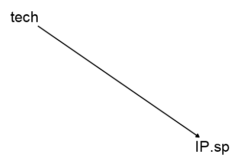

## Example

- We know that being a tech company leads you to have to spend more money on IP lawsuits
- We know that being a tech company leads you to have higher profits
- We know that IP lawsuits lower your profits

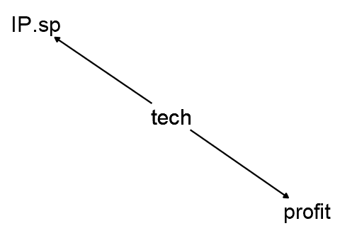

## Example

- We know that being a tech company leads you to have to spend more money on IP lawsuits
- We know that being a tech company leads you to have higher profits
- We know that IP lawsuits lower your profits

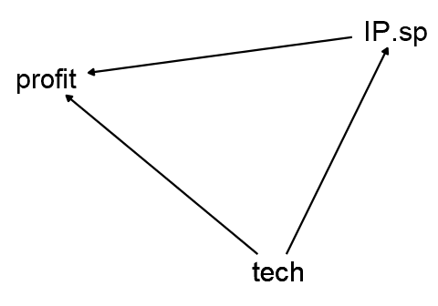

## Voila

- We have *encoded* everything we know about this particular little world in our diagram
- (well, not everything, the diagram doesn’t say whether we think these effects are positive or negative)
- Not only can we see our assumptions, but we can see how they fit together
- For example, if we were looking for the impact of *tech* on profit, we’d know that it happens directly, AND happens because tech affects `IP.spend`, which then affects profit.

## Identification

- And if we want to isolate the effect of `IP.spend` on `profit`, we can figure that out too
- We’re *identifying* just one of those arrows, the one `IP.spend -> profit`, and seeing what the effect is on that arrow!
- **If we can shut down the other arrows, there’s only one path you can walk on the diagram to get from treatment or outcome-only one kind of variation left, and it MUST be the causal effect you want**

## Identification

- Based on this graph, we can see that part of the correlation between `IP.Spend` and `profit` can be *explained by* how `tech` links the two.

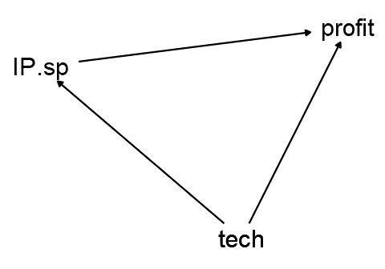

## Identification

- Since we can *explain* part of the correlation with `tech`, but we want to *identify* the part of the correlation that ISN’T explained by `tech` (the causal part), we will want to just use what isn’t explained by tech!
  - Use `tech` to explain `profit`, and take the residual
  - Use `tech` to explain `IP.spend`, and take the residual
  - The relationship between the first residual and the second residual is *causal*!

## Controlling

- This process is called “adjusting” or “controlling”. We are “controlling for `tech`” and taking out the part of the relationship that is explained by it
- (By Frisch-Waugh-Lovell, we can get the same result with a regression where we include `tech` as a control)
- In doing so, we’re looking at the relationship between `IP.spend` and `profit` *just comparing firms that have the same level of `tech`*.
- This is our “apples to apples” comparison that gives us an experiment-like result

## Controlling

```r
df <- df %>% group_by(tech) %>%
  mutate(log.profit.resid = log.profit - mean(log.profit),
         IP.spend.resid = IP.spend - mean(IP.spend)) %>% ungroup()
cor(df$log.profit.resid,df$IP.spend.resid)
```

```
## [1] -0.2812032
```

- Negative! Hooray

## Controlling

- The same idea:

```r
m1 <- lm(log.profit ~ IP.spend, data = df)
m2 <- lm(log.profit ~ IP.spend + tech, data = df)
msummary(list(m1,m2), stars = TRUE, gof_omit = 'AIC|BIC|Lik|Adj.|F')
```

## Controlling

|  | Model 1 | Model 2 |
| --- | --- | --- |
| (Intercept) | 1.377*** | 1.918*** |
|  | (0.101) | (0.099) |
| IP.spend | 0.124*** | -0.267*** |
|  | (0.030) | (0.041) |
| tech |  | 2.008*** |
|  |  | (0.162) |
| Num.Obs. | 500 | 500 |
| R2 | 0.033 | 0.262 |

* p < 0.1, ** p < 0.05, *** p < 0.01

## Controlling

- Imagine we’re looking at that relationship *within color*

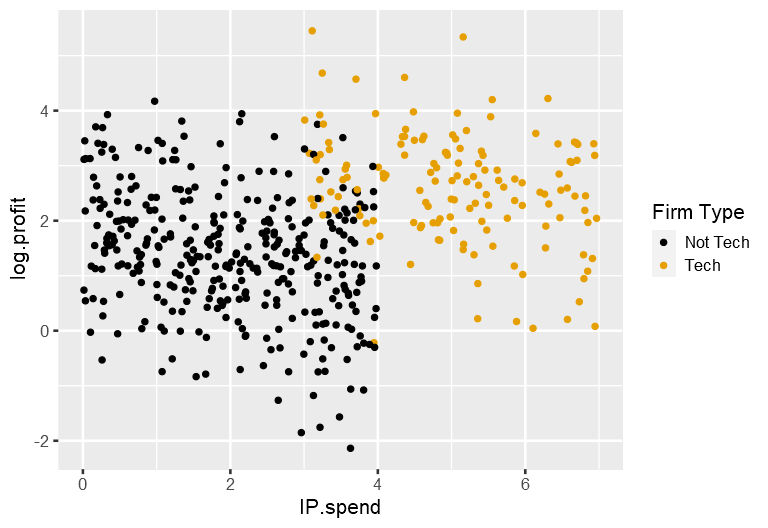

## LITERALLY

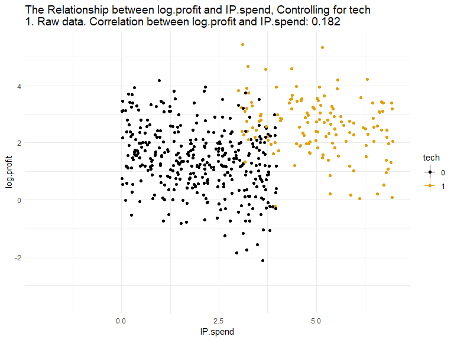

## Recap

- By controlling for `tech` (“holding it constant”) we got rid of the part of the `IP.spend`/`profit` relationship that was explained by `tech`, and so managed to *identify* the $IP.spend \rightarrow profit$ arrow, the causal effect we’re interested in!
- We correctly found that it was negative
- Remember, we made it truly negative when we created the data, all those slides ago

## Causal Diagrams

- And it was the diagram that told us to control for `tech`
- It’s going to turn out that diagrams can tell us how to identify things in much more complex circumstances - we’ll get to that soon
- But you might have noticed that it was pretty obvious what to do just by looking at the graph

## Causal Diagrams

- Can’t we just look at the data to see what we need to control for?
- After all, that would free us from having to make all those assumptions and figure out our model
- No!!!
- Why? Because for a given set of data that we see, there are *many* different data generating processes that could have made it
- Each requiring different kinds of adjustments in order to get it right

## Causal Diagrams

- We observe that `profit` (y), `IP.spend` (x), and `tech` (z) are all related… which is it?

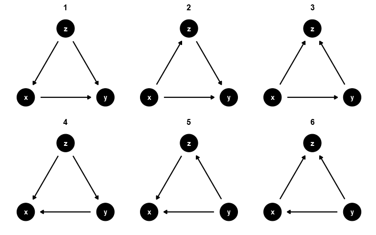

## Causal Diagrams

- With only the data to work with we have *literally no way of knowing* which of those is true
- Maybe `IP.spend` causes companies to be `tech` companies (in 2, 3, 6)
- We know that’s silly because we have an idea of what the model is
- But that’s what lets us know it’s wrong - what we know about the true model. With just the data we have no clue.

## Practice

Look at the diagram on the next page, intended to be a model of fertility decisions in Switzerland based on education and whether one comes from an agricultural family.

Ask:

1. What assumptions are in the graph?
2. Assuming the graph is true, why are Education and Fertility related?
3. Do any of the assumptions seem wrong?

## Practice

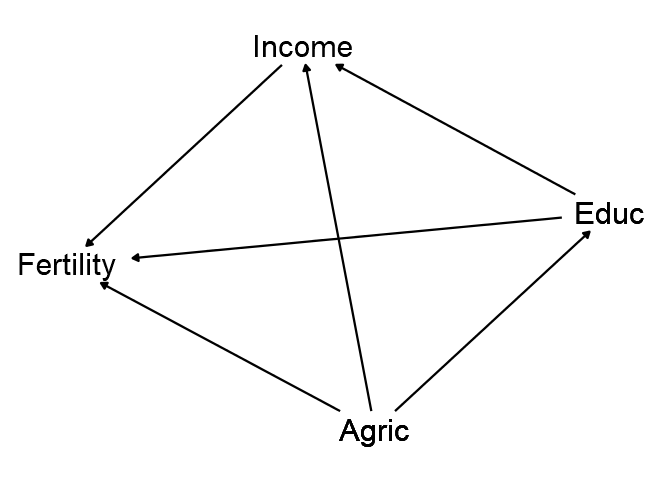

## Drawing DAGs

- So that’s what a DAG *is*. How do we *draw* one?
- This will require us to *understand* what is going on in the real world
- (especially since we won’t know the right answer, like when we simulate our own data!)
- And then represent our understanding in the diagram

## Remember

- Our goal is to *represent the underlying data-generating process*
- This is going to require some common-sense thinking
- As well as some economic intuition
- In real life, we’re not going to know what the right answer is
- Our models will be wrong. We just need them to be useful

## Steps to a Causal Diagram

1. Consider all the variables that are likely to be important in the data generating process (this includes variables you can’t observe)
2. For simplicity, combine them together or prune the ones least likely to be important
3. Consider which variables are likely to affect which other variables and draw arrows from one to the other
4. (Bonus: Test some implications of the model to see if you have the right one)

## Some Notes

- Drawing an arrow requires a *direction*. You’re making a statement!
- Omitting an arrow is a statement too - you’re saying neither causes the other (directly)
- If two variables are correlated but neither causes the other, that means they’re both caused by some other (perhaps unobserved) variable that causes both - add it!
- Remember, “cause” just means “changes the probability of”. Not all people who go to Seattle U are Catholic, but being Catholic increases the probability of going to Seattle U, so a graph of Seattle U attendance would have $Catholic \rightarrow SeattleU$ on it

## Some Notes

- There shouldn’t be any *cycles* - You shouldn’t be able to follow the arrows in one direction and end up where you started
- If there *should* be a feedback loop, like “rich get richer”, distinguish between the same variable at different points in time to avoid it
- A variable can take many values. So if sex affects something, you’d have $Sex$ as a single variable, not one for $Male$ and another for $Female$
- Don’t draw the DAG just so it will be easy to identify. Drawing the DAG does not make it so! The goal is to reflect the true omdel in the world

## So let’s do it!

- Let’s start with an econometrics classic: what is the causal effect of an additional year of education on earnings?
- That is, if we reached in and made someone get one more year of education than they already did, how much more money would they earn?

## 1. Listing Variables

- We can start with our two main variables of interest:
  - Education [we call this the “treatment” or “exposure” variable]
  - Earnings [the “outcome”]

## 1. Listing Variables

- Then, we can add other variables likely to be relevant
- Focus on variables that are likely to cause or be caused by treatment
- ESPECIALLY if they’re related both to the treatment and the outcome
- They don’t have to be things you can actually observe/measure
- Variables that affect the outcome but aren’t related to anything else aren’t really important (you’ll see why next week)

## 1. Listing Variables

- So what can we think of?
  - Ability
  - Socioeconomic status
  - Demographics
  - Phys. ed requirements
  - Year of birth
  - Location
  - Compulsory schooling laws
  - Job connections

## 3. Arrows!

- Consider which variables are likely to cause which others
- And, importantly, *which arrows you can leave out*
- The arrows you *leave out* are important to think about - you sure there’s no effect? - and prized! You need those NON-arrows to be able to causally identify anything.

## 3. Arrows

- Let’s start with our effect of interest
- Education causes earnings

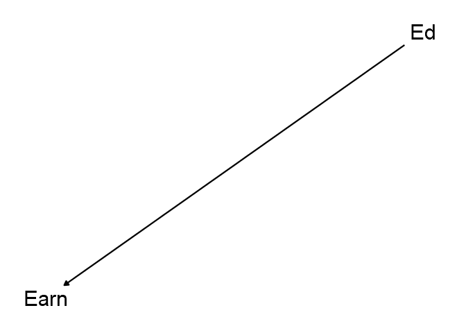

## 3. Arrows

- Remaining: Background, Year of birth, Location, Compulsory schooling, and Job Connections
- All of these but Job Connections should cause Ed

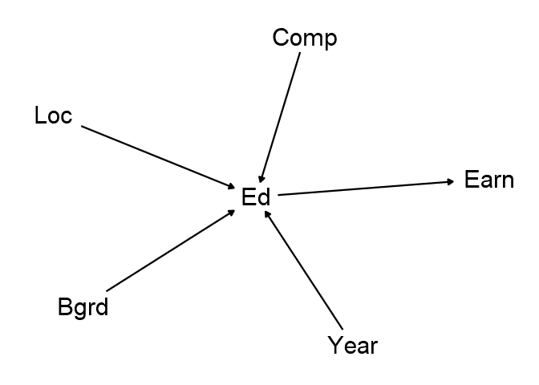

## 3. Arrows

- Seems like Year of Birth, Location, and Background should ALSO affect earnings. Job Connections, too.

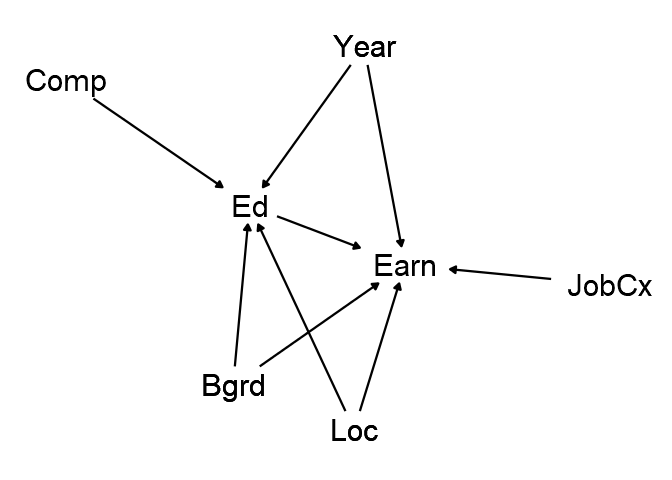

## 3. Arrows

- Job connections, in fact, seems like it should be caused by Education

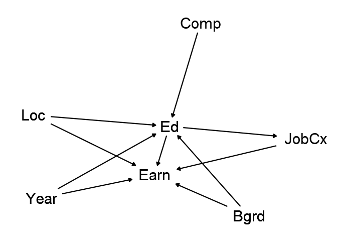

## Causal Diagrams

- And there we have it!
- Perhaps a little messy, but that can happen
- We have modeled our idea of what the data generating process looks like

## Dagitty.net

- These graphs can be drawn by hand
- Or we can use a computer to help
- We will be using dagitty.net to draw these graphs
- (You can also draw them with R code - see the slides, but you won’t need to know this)

## Dagitty.net

- Go to dagitty.net and click on “Launch”
- You will see an example of a causal diagram with nodes (variables) and arrows
- Plus handy color-coding and symbols. Green triangle for exposure/treatment, and blue bar for outcome.
- The green arrow is the “causal path” we’d like to *identify*

## Dagitty.net

- Go to Model and New Model
- Let’s recreate our Education and Earnings diagram
- Put in Education as the exposure and Earnings as the outcome (you can use longer variable names than we’ve used here)

## Dagitty.net

- Double-click on blank space to add new variables.
- Add all the variables we’re interested in.

## Dagitty.net

- Then, double click on some variable `X`, then once on another variable `Y` to get an arrow for `X -> Y`
- Fill in all our arrows!

## Dagitty.net

- Feel free to move the variables around with drag-and-drop to make it look a bit nicer
- You can even drag the arrows to make them curvy

## Practice

- Consider the causal question “does a longer night’s sleep extend your lifespan?”
1. List variables [think especially hard about what things might lead you to get a longer night’s sleep]
2. Simplify
3. Arrows
- Then, when you’re done, draw it in Dagitty.net!